# `Project:` Prevendo a Ocorrências de Crises Epiléticas

## `Date:` dezembro, 2021

## `Data Scientist:` Walter Trevisan

## `Modelagem Preditiva` (*`Machine Learning`*) - `Versão 2`

Nesta etapa, vamos continuar a etapa de **modelagem preditiva**, treinando e analisando alguns algoritmos de classificação. Para fazermos o treinamento dos modelos utilizaremos o *dataset* de treino (**`strat_train_set_v2.pck`**), e para avaliarmos a performance dos modelos utilizaremos o *dataset* de teste (**`strat_test_set.pck`**). Os dois *datasets* foram criados e preprados nas etapas anteriores.

Então, vamos realizar as seguintes atividades:

1. Carregar os *data frames* de treino (**`strat_train_set_v2.pck`**) e de teste (**`strat_test_set.pck`**);
2. Descrever as **métricas de classificação** que serão calculadas para avaliarmos os **modelos preditivos**;
3. Balancear os dados de treino e preparar os dados de teste;
4. Normalizar as **variáveis preditoras** nos dados de treino e nos dados de teste;
5. Criar os **modelos preditivos** (versão **`v2`**) utilizando os seguintes algoritmos de classificação:

> **`SGD`**: Stochastic Gradient Descent; **`KNN`**: K Nearest Neighbors; **`LR`**: Logistic Regression; **`DTC`**: Decision Tree Classifier; **`RFC`**: Random Forest Classifier; **`LDA`**: Linear Discriminant Analysis; **`NB`**: Naive bayes; **`XGBC`**: XGBoost Classifier.
1. Concluir esta etapa realizando as seguintes atividades:
> - salvar as **métricas de classificação (`v2`)** calculadas de cada modelo;
> - avaliar os resultados e escolher o **modelo preditivo** (**`v2`**) que apresentou a **melhor performance para solucionar o nosso problema de negócio**;
> - salvar o **modelo preditivo** (**`v2`**) escolhido;
> - avaliar qual foi o **melhor modelo preditivo** para o projeto, comparando os melhores modelos das versões **`v1`** e **`v2`**;
> - salvar o **melhor modelo preditivo** que resolve o problema de negócio.

## Setup:

Primeiro, vamos carregar os **pacotes e funções** que serão utilizadas neste **notebook**.

```python
# As novas versões do Pandas e Matplotlib trazem diversas mensagens de aviso ao desenvolvedor.
# Então, vamos desativar essas mensagens.
import sys # O pacote "sys" permite manipulações com o sistema operacional:
import os  # Operation System (Packages and Functions)
import warnings
if not sys.warnoptions:
    warnings.simplefilter("ignore")
warnings.simplefilter(action='ignore', category=FutureWarning)
warnings.filterwarnings("ignore", category=FutureWarning)

# Importa função para verificarmos a versão da linguagem python:
from platform import python_version

# Importando os pacote NumPy:
import numpy as np
# Importando os pacote Pandas:
import pandas as pd

# Importando pacotes para visualização de gráficos:
import matplotlib as mpl
import matplotlib.pyplot as plt
# Importa o pacote "seaborn" para criarmos gráficos estatísticos:
import seaborn as sns
%matplotlib inline

# Função para para normalizar as variáveis preditoras:
from sklearn.preprocessing import StandardScaler

# Balanceamento dos dados:
# Função para criar amostras de dados de forma estratificada:
from sklearn.model_selection import StratifiedShuffleSplit
# Função de cálculo para plotar a "ROC Curve":
from sklearn.metrics import roc_curve

# Machine Learning imports
# Importando o pacote do Scikit-Learn:
import sklearn as skl
# Importando algoritmos de classificação:
from sklearn.linear_model import SGDClassifier # Classificador SGD.
from sklearn.neighbors import KNeighborsClassifier # Classificador KNN.
from sklearn.linear_model import LogisticRegression
from sklearn.tree import DecisionTreeClassifier
from sklearn.ensemble import RandomForestClassifier
from sklearn.discriminant_analysis import LinearDiscriminantAnalysis
from sklearn.naive_bayes import GaussianNB
import xgboost as xgb
from xgboost import XGBClassifier

# Definindo uma "semente" para reproduzir os mesmos dados nas tarefas de amostragem,
# balanceamento dos dados e treinamento dos modelos preditivos:
SEED = 42

# Definindo o diretório raiz (Root) onde serão armazenados todas as informações
# (Imagens, Gráficos, Objetos, Dados, Modelos de ML, etc...) do projeto.
# Diretório Raiz (Root) do Projeto:
ROOT_DIR = "."

# Path: onde ficarão armazenados os "Objetos" (Estrututras de Dados) relacionados ao Projeto:
OBJ_PATH = os.path.join(ROOT_DIR, "objects")
# Criando o diretório, se ele não existir:
os.makedirs(OBJ_PATH, exist_ok=True)

# Path: onde ficarão armazenados os "datasets" (arquivos "csv") e os "objetos" (Data Frames) do Projeto:
DATA_PATH = os.path.join(ROOT_DIR, "data")
# Criando o diretório, se ele não existir:
os.makedirs(DATA_PATH, exist_ok=True)

# Path: onde serão armazenadas as "Imagens" (Figuras e Gráficos) do Projeto:
GRAPHICS_PATH = os.path.join(ROOT_DIR, "images", "graphics")
# Criando o diretório, se ele não existir:
os.makedirs(GRAPHICS_PATH, exist_ok=True)

# Path: onde ficarão armazenados os "Modelos Preditivos" (Machine Learning) relacionados ao Projeto:
ML_PATH = os.path.join(ROOT_DIR, "models")
# Criando o diretório, se ele não existir:
os.makedirs(ML_PATH, exist_ok=True)

# Path: onde estão armazenadas as classes e funções que serão utilizadas neste notebook:
LIB_PATH = os.path.join(ROOT_DIR, "library")

# Adicionando o diretório "./library" ao 'path' do Sistema, para podermos importar classes e funções que serão
# utilizadas neste notebook:
sys.path.append(LIB_PATH)

# Importando para este notebook, as classes e funções definidas no módulo "data_science_library.py":
import data_science_library as dslib

# Importando para este notebook, as classes e funções definidas no módulo "plot_library.py":
import plot_library as ptlib

# Importando para este notebook, as classes e funções definidas no módulo "machine_learning_library.py":
import machine_learning_library as mllib

# Criando um objeto para calularmos os tempos gastos de treinamento:
ept = dslib.ElapsedTime(builder_msg=False)

print("Setup Complete!")
```

```
Setup Complete!
```

```python
# Versões dos pacotes usados neste jupyter notebook:
print("Versões dos pacotes usados neste jupyter notebook:")
print("Python      : {}".format(python_version()))
print("Numpy       : {}".format(np.__version__))
print("Pandas      : {}".format(pd.__version__))
print("Matplotlib  : {}".format(mpl.__version__))
print("Seaborn     : {}".format(sns.__version__))
print("Scikit-Learn: {}".format(skl.__version__))
print("xgboost     : {}".format(xgb.__version__))
```

```
Versões dos pacotes usados neste jupyter notebook:
Python      : 3.7.11
Numpy       : 1.21.2
Pandas      : 1.3.4
Matplotlib  : 3.5.0
Seaborn     : 0.11.2
Scikit-Learn: 1.0.1
xgboost     : 0.90
```

## 1- Carregar os *data frames* de treino e teste

```python
# Carregando o "data frame" de treino ("strat_train_set_v2"):
train_df = dslib.pickle_object_load(
    path=DATA_PATH, file="strat_train_set_v2.pck",
    msg="O arquivo 'strat_train_set_v2.pck' (data frame) foi carregado com sucesso!"
)

# Visualizando os primeiros registros:
train_df.head()
```

```
O arquivo 'strat_train_set_v2.pck' (data frame) foi carregado com sucesso!
```

|  | X1 | X2 | X3 | X4 | X5 | X6 | X7 | X8 | X9 | X10 | ... | X171 | X172 | X173 | X174 | X175 | X176 | X177 | X178 | y | target |
| --- | --- | --- | --- | --- | --- | --- | --- | --- | --- | --- | --- | --- | --- | --- | --- | --- | --- | --- | --- | --- | --- |
| 0 | 57 | -36 | -111 | -185 | -257 | -324 | -369 | -394 | -387 | -362 | ... | 703 | 669 | 565 | 461 | 345 | 207 | 64 | -88 | 1 | 1 |
| 1 | -69 | -67 | -60 | -62 | -66 | -66 | -59 | -56 | -51 | -60 | ... | -68 | -63 | -53 | -42 | -32 | -24 | -13 | -4 | 2 | 0 |
| 2 | -78 | -75 | -68 | -57 | -26 | -19 | 11 | 13 | 25 | 10 | ... | 30 | 23 | 29 | 40 | 52 | 44 | 39 | 21 | 5 | 0 |
| 3 | 1 | 2 | 11 | 21 | 25 | 35 | 43 | 50 | 54 | 60 | ... | 19 | 15 | 14 | 14 | 15 | 15 | 9 | 3 | 2 | 0 |
| 4 | -111 | -105 | -100 | -91 | -84 | -76 | -74 | -68 | -54 | -47 | ... | 3 | 5 | 8 | 10 | 6 | 1 | -3 | -13 | 2 | 0 |

5 rows × 180 columns

```python
# Carregando o "data frame" de teste ("strat_test_set"):
test_df = dslib.pickle_object_load(
    path=DATA_PATH, file="strat_test_set.pck",
    msg="O arquivo 'strat_test_set.pck' (data frame) foi carregado com sucesso!"
)

# Visualizando os primeiros registros:
test_df.head()
```

```
O arquivo 'strat_test_set.pck' (data frame) foi carregado com sucesso!
```

|  | Unnamed: 0 | X1 | X2 | X3 | X4 | X5 | X6 | X7 | X8 | X9 | ... | X170 | X171 | X172 | X173 | X174 | X175 | X176 | X177 | X178 | y |
| --- | --- | --- | --- | --- | --- | --- | --- | --- | --- | --- | --- | --- | --- | --- | --- | --- | --- | --- | --- | --- | --- |
| 0 | X21.V1.794 | 403 | 501 | 631 | 710 | 679 | 526 | 297 | 25 | -274 | ... | 655 | 669 | 592 | 422 | 160 | -160 | -471 | -754 | -924 | 1 |
| 1 | X20.V1.321 | 17 | 25 | 40 | 46 | 31 | 1 | -19 | -30 | -28 | ... | -1 | -33 | -54 | -52 | -26 | -1 | 19 | 19 | -3 | 4 |
| 2 | X15.V1.274 | -643 | -726 | -725 | -628 | -472 | -239 | 33 | 363 | 679 | ... | -373 | -400 | -450 | -523 | -556 | -556 | -454 | -276 | -30 | 1 |
| 3 | X19.V1.354 | -47 | -11 | 28 | 77 | 141 | 211 | 246 | 240 | 193 | ... | -65 | -33 | -7 | 14 | 27 | 48 | 77 | 117 | 170 | 1 |
| 4 | X12.V1.132 | -35 | -40 | -41 | -52 | -64 | -83 | -100 | -101 | -91 | ... | -72 | -64 | -64 | -67 | -66 | -64 | -70 | -81 | -99 | 3 |

5 rows × 180 columns

## 2- Descrição das `métricas de classificação`:

### Métricas: `Accuracy`, `Precision`, `Recall`, `f1-score` e `ROC Curve (AUC)`

### `Accuracy`:

A **acurácia** do modelo mede a taxa de acertos das classes *True Positive* e *True Negative*, sendo calculada pela fórmula abaixo:

**`Accuracy = (TP + TN)/(TP + TN + FP + FN)`**, onde:

1. **`TP`** é o número de *verdadeiros positivos*;
2. **`TN`** é o número de *verdadeiros negativos*;
3. **`FP`** é o número de *falsos positivos*.
4. **`FN`** é o número de *falsos negativos*.

Um classificador perfeito teria apenas *verdadeiros positivos* (**TP**) e *verdadeiros negativos* (**TN**), ou seja, sua **matriz de confusão** teria valores diferentes de zero somente na sua diagonal principal (superior esquerda para a inferior direita), ou seja, a sua acurácia (**`accuracy`**) seria de **100%**.

### `Precision`:

Uma outra métrica interessante a ser observada na *matriz de confusão* é a `acurácia das previsões positivas`; que é chamada de *precisão (precision)* do classificador e é calculada pela fórmula abaixo:

**`Precision = TP/(TP + FP)`**, onde:

1. **`TP`** é o número de *verdadeiros positivos*;
2. **`FP`** é o número de *falsos positivos*.

### `Recall`:

Entretanto, a precisão é utilizada em conjunto com outra métrica chamada *revocação (recall)*, também conhecida como *sensibilidade* ou *taxa de verdadeiros positivos (TPR)*: esta é a taxa de `instâncias positivas que são corretamente detectadas` pelo classificador, sendo calculada pel fórmula abaixo:

**`Recall = TP/(TP + FN)`**, onde:

1. **`TP`** é o número de *verdadeiros positivos*;
2. **`FN`** é o número de *falsos negativos*.

### `f1-score`:

Muitas vezes, é conveniente combinarmos **precisão** e **revocação** em uma única métrica chamada *pontuação F1 (f1 score)*, principalmente se precisarmos comparar dois ou mais classificadores.

A *pontuação F1* é a *média harmônica* da **precisão** e **revocação**, sendo calculada pela fórmula abaixo:

**`F1 = TP/(TP + (FN + FP)/2)`**, onde:

1. **`TP`** é o número de *verdadeiros positivos*;
2. **`FN`** é o número de *falsos negativos*;
3. **`FP`** é o número de *falsos positivos*.

Enquanto a média regular trata igualmente todos os valores, a média harmônica dá muito mais peso aos valores mais baixos, ou seja, o classificador só obterá uma *pontuação F1* alta, se a **revocação** e a **precisão** forem altas.

### `ROC Curve (AUC)`

A curva **ROC** (*características operacionais do receptor*) é outra ferramenta comum utilizada com classificadores binários. É muito semelhante à curva de **`precision/recall`**, mas, em vez de plotar a **precision versus recall**, a curva **ROC** plota a *taxa de verdadeiros positivos* (*TPR = True Positive Rate*), que é um outro nome dado para *recall*, versus a *taxa de falsos positivos* (*FPR = False Positive Rate*). O *FPR* é a razão de instâncias negativas incorretamente classificadas como positivas. É igual a 1 menos *taxa de verdadeiros negativos* (*TNR = True Negative Rate*), que é a razão de instâncias negativas que são corretamente classificadas como negativas. A *TNR* também é chamada de *especificidade*.

Portanto, a *Curva ROC* plota a *`sensibilidade (recall)` versus `1 - especificidade`*.

Equações:

1. **`TPR = TP/(TP + FN)`** --> *True Positive Rate*, ou também *`recall`* ou também *`sensibilidade`*
2. **`FPR = FP/(FP + TN)`** --> *False Positive Rate*
3. **`TNR = TN/(TN + FP)`** --> *True Negative Rate*, ou também *especificidade*
4. **`FPR = 1 - TNR`** ou também **`FPR = 1 - especificidade`**

Então, para plotarmos a *ROC curve*, primeiro precisamos calcular a **TPR** e a **FPR** para vários valores de *thresholds* (limiares) utilizando a função *`roc_curve()`*.

Mas, a função `roc_curve()` utiliza as **pontuações de decisão** (ao invés das previsões) de todas as instâncias do nosso dataset, ou seja, precisamos primeiro calcular estas pontuações (`scores`) de decisão utilizando o método `decision_function` da função `cross_val_predict()`.

Entretando, devido ao modo como funcionam, alguns classificadores (por exemplo: a classe `KNeighborsClassifier`) não possuem um método `decision_function()`. Em vez disso, eles possuem um método chamado `predict_proba()`. Este método retorna um array que contém uma linha por instância e uma coluna por classe, cada uma contendo a probabilidade de a instância dada pertencer à classe dada (por exemplo, neste projeto, 70% de chance de um cliente estar insatisfeito). Portanto, quando utilizarmos estes classificadores, primeiro precisaremos calcular as probabilidades com o método `predict_proba()`, e, então, em seguida calcularemos as *pontuações de decisão* utilizando a probabilidade da classe positiva como sendo a pontuação.

Observando o gráfico da **Curva ROC**, quanto maior a *`TPR (recall)`*, mais falsos positivos (*`FPR`*) o classificador produz, ou seja, menor é a sua **precisão** (*`precision`*). A linha pontilhada representa a curva ROC de um classificador puramente aleatório; um bom classificador fica mais distante dessa linha possível (em direção ao canto superior esquerdo)!

Uma forma de compararmos dois ou mais classificadores é medirmos a **área abaixo da curva** (*`AUC = Area Under Curve`*). Um classificador perfeito terá um *`ROC AUC = 1`*, enquanto que um classificador puramente aleatório terá um *`ROC AUC = 0.5`*.

## 3- Balanceamento do *dataset* de treino e preparação dos *datasets* de treino e teste

Para fazermos o balanceamento dos dados de treino aplicaremos o método de **amostragem estratificada**, utilizando a nossa variável target (**`y`**), para termos as mesmas proporções da classe **1** e das outras classes (**2, 3, 4 e 5**) nos dois conjuntos de dados gerados, ou seja, teremos um conjunto de dados com **75%** dos registros e outro conjunto de dados com **25%** dos registros. O conjunto de dados com **25%** dos registros e o conjunto de dados com a categoria igual a **1** formarão o *dataset* de treino que utilizaremos para o treinamento dos modelos preditivos. Após o balanceamento a quantidade de registros para cada categoria será a mesma, ou seja, **50%** de registros para cada categoria (**`target = 0`** e **`target = 1`**).

**amostragem estratificada**: a população é dividida em subgrupos homogêneos, chamados de *estratos*, e o número certo de instâncias de cada estrato é amostrado para garantir que o conjunto de testes seja representativo da população em geral.

```python
# Filtrando todos os registros da classe positiva ("target = 1"), ou seja, estamos filtrando 20% dos pacientes
# que tiveram crise epilética:
# Criando um índice:
index = (train_df['target'] == 1)
# Filtrando os registros do dataset de treino:
train_cat_1_df = train_df[index]
# Reset no índice do data frame:
train_cat_1_df.reset_index(drop=True, inplace=True)

# Filtrando todos os registros da classe negativa ("target = 0"), ou seja, estamos filtrando 80% dos pacientes
# que não tiveram crise epilética:
# Criando um índice:
index = (train_df['target'] == 0)
# Filtrando os registros do dataset de treino:
train_cat_0_df = train_df[index]
# Reset no índice do data frame:
train_cat_0_df.reset_index(drop=True, inplace=True)
```

```python
# Fazendo o balanceamento dos dados de treino:
# Criando a instância:
split = StratifiedShuffleSplit(n_splits=1, test_size=0.25, random_state=SEED)

# Criando os datasets de 75% e 25% utilizando amostragem estratificada:
for dataset_75_index, dataset_25_index in split.split(train_cat_0_df, train_cat_0_df["y"]):
    strat_75_set = train_cat_0_df.loc[dataset_75_index]
    strat_25_set = train_cat_0_df.loc[dataset_25_index]

# Reset no índice do data frame de 25%:
strat_25_set.reset_index(drop=True, inplace=True)

# Criando o dataset de treino balanceado:
train_bal_df = pd.concat(objs=[train_cat_1_df,strat_25_set], axis=0, ignore_index=True)
# Embaralhando o data frame "train_bal_df" de forma aleatória:
train_bal_df = train_bal_df.sample(n = len(train_bal_df), random_state=SEED, ignore_index=True)
```

```python
# Verificando a contagem de cada categoria do data frame balanceado:
dslib.percent_count_feature(df=train_bal_df, feature='target')
```

| target | Total | Percent |
| --- | --- | --- |
| 0 | 1840 | 0.5 |
| 1 | 1840 | 0.5 |

**Análise:** podemos observar que o dataset de treino foi balanceado com **50%** de registros para cada uma das categorias: **`target = 0`** e **`target = 1`**.

### Preparando os dados de treino: `X_train_bal` e `y_train_bal`

```python
# Criando a matrizes "X_train_bal" e o vetor "y_train_bal":
# Criando uma lista com os nomes das variáveis preditoras:
features = list(train_bal_df.columns.drop(labels=['y', 'target']))
# Criando a matriz "X_train_bal":
X_train_bal = train_bal_df[features].values
# Criando o vetor "y_train_bal":
y_train_bal = train_bal_df['target'].values
print("Dados de treino:")
print("X_train_bal: {}".format(X_train_bal.shape))
print("y_train_bal: {}".format(y_train_bal.shape))
```

```
Dados de treino:
X_train_bal: (3680, 178)
y_train_bal: (3680,)
```

### Preparando os dados de teste: `X_test` e `y_test`

```python
# Fazendo "feature engineering" nos dados de teste:
test_df = dslib.feature_engineering(df=test_df)
```

```python
# Criando a matrizes "X_test" e o vetor "y_test":
# Criando uma lista com os nomes das variáveis preditoras:
features = list(test_df.columns.drop(labels=['y', 'target']))
# Criando a matriz "X_test":
X_test = test_df[features].values
# Criando o vetor "y_test":
y_test = test_df['target'].values
print("Dados de teste:")
print("X_test: {}".format(X_test.shape))
print("y_test: {}".format(y_test.shape))
```

```
Dados de teste:
X_test: (2300, 178)
y_test: (2300,)
```

## 3- Normalizar as variáveis preditoras nos dados de treino e teste

Para normalizar as variáveis preditoras, ou seja, colocar os seus valores numéricos na mesma escala, utilizaremos a função **[StandardScaler](https://scikit-learn.org/stable/modules/generated/sklearn.preprocessing.StandardScaler.html)**, que pertence ao pacote **`sklearn.preprocessing`**.

```python
# Criando o objeto "scaler":
scaler = StandardScaler()

# Fit nos dados de treino:
scaler.fit(X_train_bal)

# Salvando o objeto "scaler" na pasta "./objects":
dslib.pickle_object_save (
    path=OBJ_PATH, file="scaler_v2.pck", object_name=scaler,
    msg="O arquivo 'scaler_v2.pck' (object) foi salvo com sucesso!")
```

```
O arquivo 'scaler_v2.pck' (object) foi salvo com sucesso!
```

```python
# Aplicando a normalização nos dados de treino:
X_train_bal = scaler.transform(X=X_train_bal)

# Aplicando a normalização nos dados de teste:
X_test = scaler.transform(X=X_test)
```

**Análise:** portanto, temos o nosso *dataset* de *treino* **balanceado** e pronto para ser utilizado na **modelagem preditiva**.

## 5- Criação de modelos preditivos (`versão 2`)

Agora, vamos realizar a etapa de criação dos **modelos preditivos**, realizando o treinamento e validação de alguns algoritmos de *machine learning*.

Nesta versão (**v2**), vamos treinar e validar os modelos utilizando as seguintes premissas:

- utilização de **todas** as variáveis preditoras (`X1, X2, ..., X178`);
- normalização das variáveis preditoras (`X1, X2, ..., X178`);
- balanceamento do *dataset* de treino, onde eliminamos registros da classe majoritária (`target = 0`) aplicando o método estatístico de **amostragem estratificada**.

Como equilibramos nossos dados de treinamento, através do **balanceamento**, vamos definir nosso limite em **0.5** para rotular uma amostra prevista como positiva. Portanto, as probabilidades previstas que foram acima deste valor (**THRESHOLD**) serão **rotuladas** como positiva (**`target = 1`**), ou seja, significa que os **pacientes terão crises epiléticas**.

```python
# Definindo o valor limite (THRESHOLD):
THRESHOLD = 0.5
```

```python
# Criando um dicionário dos modelos que serão treinados:
models = {
    'SGD' :SGDClassifier(loss='modified_huber', max_iter=1000, tol=1e-3, random_state=SEED),
    'KNN' :KNeighborsClassifier(n_jobs=-1),
    'LR'  :LogisticRegression(random_state = SEED),
    'DTC' :DecisionTreeClassifier(random_state=SEED),
    'RFC' :RandomForestClassifier(random_state=SEED),
    'LDA' :LinearDiscriminantAnalysis(solver='eigen', shrinkage='auto'),
    'NB'  :GaussianNB(),
    'XGBC':XGBClassifier(random_state=SEED, n_jobs=-1)
}
```

## 5.1- [SGD](https://scikit-learn.org/stable/modules/generated/sklearn.linear_model.SGDClassifier.html) (Stochastic Gradient Descent):

```python
# Inicia o treinamento e avaliação:
ept.start(msg="Iniciando o treinamento/avaliação com o 'SGD'...")

# Treinando e avalidando o classificador binário com o SGD:
sgd, sgd_train_mtcs, sgd_test_mtcs = mllib.train_validate_binary_clf_model(
    classifier=models['SGD'], X_train=X_train_bal, y_train=y_train_bal, X_valid=X_test, y_valid=y_test, threshold=THRESHOLD
)

# Fim do treinamento e avaliação:
ept.end(msg="\nTempo gasto para o treinamento/avaliação com o 'SGD':")
```

```
Iniciando o treinamento/avaliação com o 'SGD'...

Training Metrics:
AUC      : 0.5559
Accuracy : 0.5546
Precision: 0.5569
Recall   : 0.5348
f1-score : 0.5456

Validation Metrics:
AUC      : 0.5395
Accuracy : 0.5565
Precision: 0.2297
Recall   : 0.5174
f1-score : 0.3182

Tempo gasto para o treinamento/avaliação com o 'SGD': 0.18 seconds.
```

**Análise:**

1. com o classificador **`SGD`** obtivemos uma taxa de **acurácia** de **55.65%** nos dados de teste, ou seja, é a porcentagem de pacientes, classificados corretamente por ele, que **terão uma crise epilética** e que **não terão uma crise epilética**. Portanto, o nosso classificador **`SGD`** apresentou uma performance **muito ruim**;
2. com o nosso classificador **`SGD`** obtivemos uma taxa de **precisão** de **22.97%** nos dados de teste, ou seja, é a porcentagem de pacientes, classificados corretamente por ele, que **terão uma crise epilética**. Portanto, o nosso modelo apresentou uma performance **muito ruim** porque em apenas **23%** dos pacientes ele acertou que os mesmos **terão uma crise epilética**;
3. com o nosso classificador **`SGD`** obtivemos uma taxa de **revocação** de **51.74%** nos dados de teste, ou seja, é a porcentagem de pacientes, que ele conseguiu detectar, que **terão uma crise epilética**. Portanto, o nosso modelo apresentou uma performance **muito ruim** porque em apenas **52%** dos pacientes ele conseguiu detectar que os mesmos **terão uma crise epilética**;
4. com o classificador **`SGD`** obtivemos uma **`pontuação F1`** **muito baixa**, porque as taxas de **precisão** e **revocação** também foram muito baixas.

### `ROC Curve`

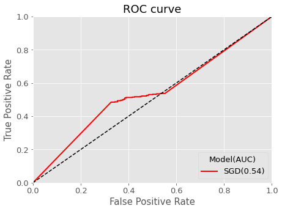

```python
# Dados de teste: obtendo as probabilidades da classe positiva (1):
y_test_preds = sgd.predict_proba(X_test)[:,1]

# Calculando o "FPR", "TPR" e "Thresholds":
fpr, tpr, thresholds = roc_curve(y_test, y_test_preds)

# Plot da "Curva ROC":
ptlib.plot_roc_curve(
    fpr, tpr, auc=sgd_test_mtcs['auc'], auc_decimals=2, plot_style='ggplot', color='red', line_width=2,
    title='ROC curve', title_fontsize=18, labels_fontsize=15, ticks_fontsize=13,
    legendtitle='Model(AUC)', legendtitle_fontsize=13, legend_label='SGD', legend_fontsize=13,
    width=7, height=5, figure_id=None, figure_path=GRAPHICS_PATH,
    figure_file_format="png", figure_file_extension=".png", tight_layout=True, dpi=300
)
```

**Análise:**

Podemos observar que o nosso classificador **`SGD`** apresentou uma *`ROC curve`* **muito distante** do *canto superior esquerdo*. Observe que a métrica **`AUC = 53.95%`** ficou **muito abaixo** do valor proposto de avaliação do projeto (**`AUC = ~99%`**).

## 5.2- [KNN](https://scikit-learn.org/stable/modules/generated/sklearn.neighbors.KNeighborsClassifier.html) (K Nearest Neighbors):

```python
# Inicia o treinamento e avaliação:
ept.start(msg="Iniciando o treinamento/avaliação com o 'KNN'...")

# Treinando e avalidando o classificador binário com o KNN:
knn, knn_train_mtcs, knn_test_mtcs = mllib.train_validate_binary_clf_model(
    classifier=models['KNN'], X_train=X_train_bal, y_train=y_train_bal, X_valid=X_test, y_valid=y_test, threshold=THRESHOLD
)

# Fim do treinamento e avaliação:
ept.end(msg="\nTempo gasto para o treinamento/avaliação com o 'KNN':")
```

```
Iniciando o treinamento/avaliação com o 'KNN'...

Training Metrics:
AUC      : 0.9973
Accuracy : 0.8837
Precision: 0.9958
Recall   : 0.7707
f1-score : 0.8689

Validation Metrics:
AUC      : 0.9439
Accuracy : 0.9409
Precision: 0.9576
Recall   : 0.737
f1-score : 0.8329

Tempo gasto para o treinamento/avaliação com o 'KNN': 1.11 seconds.
```

**Análise:**

1. com o classificador **`KNN`** obtivemos uma taxa de **acurácia** de **94.09%** nos dados de teste, ou seja, é a porcentagem de pacientes, classificados corretamente por ele, que **terão uma crise epilética** e que **não terão uma crise epilética**. Portanto, o nosso classificador **`KNN`** apresentou uma performance **excelente**;
2. com o nosso classificador **`KNN`** obtivemos uma taxa de **precisão** de **95.76%** nos dados de teste, ou seja, é a porcentagem de pacientes, classificados corretamente por ele, que **terão uma crise epilética**. Portanto, o nosso modelo apresentou uma performance **excelente** porque em **96%** dos pacientes ele acertou que os mesmos **terão uma crise epilética**;
3. com o nosso classificador **`KNN`** obtivemos uma taxa de **revocação** de **73.70%** nos dados de teste, ou seja, é a porcentagem de pacientes, que ele conseguiu detectar, que **terão uma crise epilética**. Portanto, o nosso modelo apresentou uma performance **boa** porque em **74%** dos pacientes ele conseguiu detectar que os mesmos **terão uma crise epilética**;
4. com o classificador **`KNN`** obtivemos uma **`pontuação F1`** **muito alta**, porque as taxas de **precisão** e **revocação** também foram muito altas.

### `ROC Curve`

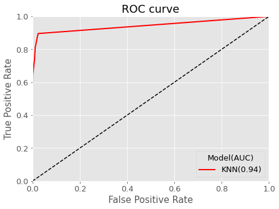

```python
# Dados de teste: obtendo as probabilidades da classe positiva (1):
y_test_preds = knn.predict_proba(X_test)[:,1]

# Calculando o "FPR", "TPR" e "Thresholds":
fpr, tpr, thresholds = roc_curve(y_test, y_test_preds)

# Plot da "Curva ROC":
ptlib.plot_roc_curve(
    fpr, tpr, auc=knn_test_mtcs['auc'], auc_decimals=2, plot_style='ggplot', color='red', line_width=2,
    title='ROC curve', title_fontsize=18, labels_fontsize=15, ticks_fontsize=13,
    legendtitle='Model(AUC)', legendtitle_fontsize=13, legend_label='KNN', legend_fontsize=13,
    width=7, height=5, figure_id=None, figure_path=GRAPHICS_PATH,
    figure_file_format="png", figure_file_extension=".png", tight_layout=True, dpi=300
)
```

**Análise:**

Podemos observar que o nosso classificador **`KNN`** apresentou uma *`ROC curve`* **muito próxima** do *canto superior esquerdo*. Observe também que a métrica **`AUC = 94.39%`** ficou **muito próxima** do valor proposto de avaliação do projeto (**`AUC = ~99%`**).

## 5.3- [Logistic Regression](https://scikit-learn.org/stable/modules/generated/sklearn.linear_model.LogisticRegression.html):

```python
# Inicia o treinamento e avaliação:
ept.start(msg="Iniciando o treinamento/avaliação com o 'LR'...")

# Treinando e avalidando o classificador binário com o LR:
lr, lr_train_mtcs, lr_test_mtcs = mllib.train_validate_binary_clf_model(
    classifier=models['LR'], X_train=X_train_bal, y_train=y_train_bal, X_valid=X_test, y_valid=y_test, threshold=THRESHOLD
)

# Fim do treinamento e avaliação:
ept.end(msg="\nTempo gasto para o treinamento/avaliação com o 'LR':")
```

```
Iniciando o treinamento/avaliação com o 'LR'...

Training Metrics:
AUC      : 0.6107
Accuracy : 0.6266
Precision: 0.662
Recall   : 0.5174
f1-score : 0.5808

Validation Metrics:
AUC      : 0.5357
Accuracy : 0.667
Precision: 0.2932
Recall   : 0.4717
f1-score : 0.3617

Tempo gasto para o treinamento/avaliação com o 'LR': 0.13 seconds.
```

**Análise:**

1. com o classificador **`LR`** obtivemos uma taxa de **acurácia** de **66.70%** nos dados de teste, ou seja, é a porcentagem de pacientes, classificados corretamente por ele, que **terão uma crise epilética** e que **não terão uma crise epilética**. Portanto, o nosso classificador **`LR`** apresentou uma performance **razoável**;
2. com o nosso classificador **`LR`** obtivemos uma taxa de **precisão** de **29.32%** nos dados de teste, ou seja, é a porcentagem de pacientes, classificados corretamente por ele, que **terão uma crise epilética**. Portanto, o nosso modelo apresentou uma performance **muito ruim** porque em apenas **29%** dos pacientes ele acertou que os mesmos **terão uma crise epilética**;
3. com o nosso classificador **`LR`** obtivemos uma taxa de **revocação** de **47.17%** nos dados de teste, ou seja, é a porcentagem de pacientes, que ele conseguiu detectar, que **terão uma crise epilética**. Portanto, o nosso modelo apresentou uma performance **muito ruim** porque em apenas **47%** dos pacientes ele conseguiu detectar que os mesmos **terão uma crise epilética**;
4. com o classificador **`LR`** obtivemos uma **`pontuação F1`** **muito baixa**, porque as taxas de **precisão** e **revocação** também foram muito baixas.

### `ROC Curve`

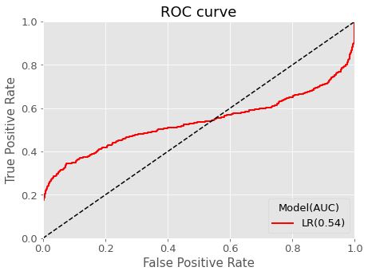

```python
# Dados de teste: obtendo as probabilidades da classe positiva (1):
y_test_preds = lr.predict_proba(X_test)[:,1]

# Calculando o "FPR", "TPR" e "Thresholds":
fpr, tpr, thresholds = roc_curve(y_test, y_test_preds)

# Plot da "Curva ROC":
ptlib.plot_roc_curve(
    fpr, tpr, auc=lr_test_mtcs['auc'], auc_decimals=2, plot_style='ggplot', color='red', line_width=2,
    title='ROC curve', title_fontsize=18, labels_fontsize=15, ticks_fontsize=13,
    legendtitle='Model(AUC)', legendtitle_fontsize=13, legend_label='LR', legend_fontsize=13,
    width=7, height=5, figure_id=None, figure_path=GRAPHICS_PATH,
    figure_file_format="png", figure_file_extension=".png", tight_layout=True, dpi=300
)
```

**Análise:**

Podemos observar que o nosso classificador **`LR`** apresentou uma *`ROC curve`* **muito distante** do *canto superior esquerdo*. Observe também que a métrica **`AUC = 53.57%`** ficou **muito abaixo** do valor proposto de avaliação do projeto (**`AUC = ~99%`**).

## 5.4- [DTC](https://scikit-learn.org/stable/modules/generated/sklearn.tree.DecisionTreeClassifier.html) (Decision Tree Classifier):

```python
# Inicia o treinamento e avaliação:
ept.start(msg="Iniciando o treinamento/avaliação com o 'DTC'...")

# Treinando e avalidando o classificador binário com o DTC:
dtc, dtc_train_mtcs, dtc_test_mtcs = mllib.train_validate_binary_clf_model(
    classifier=models['DTC'], X_train=X_train_bal, y_train=y_train_bal, X_valid=X_test, y_valid=y_test, threshold=THRESHOLD
)

# Fim do treinamento e avaliação:
ept.end(msg="\nTempo gasto para o treinamento/avaliação com o 'DTC':")
```

```
Iniciando o treinamento/avaliação com o 'DTC'...

Training Metrics:
AUC      : 1.0
Accuracy : 1.0
Precision: 1.0
Recall   : 1.0
f1-score : 1.0

Validation Metrics:
AUC      : 0.9101
Accuracy : 0.907
Precision: 0.7064
Recall   : 0.9152
f1-score : 0.7973

Tempo gasto para o treinamento/avaliação com o 'DTC': 0.64 seconds.
```

**Análise:**

1. com o classificador **`DTC`** obtivemos uma taxa de **acurácia** de **90.70%** nos dados de teste, ou seja, é a porcentagem de pacientes, classificados corretamente por ele, que **terão uma crise epilética** e que **não terão uma crise epilética**. Portanto, o nosso classificador **`DTC`** apresentou uma performance **muito boa**;
2. com o nosso classificador **`DTC`** obtivemos uma taxa de **precisão** de **70.64%** nos dados de teste, ou seja, é a porcentagem de pacientes, classificados corretamente por ele, que **terão uma crise epilética**. Portanto, o nosso modelo apresentou uma performance **boa** porque em **70%** dos pacientes ele acertou que os mesmos **terão uma crise epilética**;
3. com o nosso classificador **`DTC`** obtivemos uma taxa de **revocação** de **91.52%** nos dados de teste, ou seja, é a porcentagem de pacientes, que ele conseguiu detectar, que **terão uma crise epilética**. Portanto, o nosso modelo apresentou uma performance **muito boa** porque em **91%** dos pacientes ele conseguiu detectar que os mesmos **terão uma crise epilética**;
4. com o classificador **`DTC`** obtivemos uma **`pontuação F1`** **média**, porque a taxa de **precisão** foi baixa e a taxa de **revocação** foi alta.

### `ROC Curve`

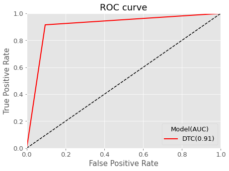

```python
# Dados de teste: obtendo as probabilidades da classe positiva (1):
y_test_preds = dtc.predict_proba(X_test)[:,1]

# Calculando o "FPR", "TPR" e "Thresholds":
fpr, tpr, thresholds = roc_curve(y_test, y_test_preds)

# Plot da "Curva ROC":
ptlib.plot_roc_curve(
    fpr, tpr, auc=dtc_test_mtcs['auc'], auc_decimals=2, plot_style='ggplot', color='red', line_width=2,
    title='ROC curve', title_fontsize=18, labels_fontsize=15, ticks_fontsize=13,
    legendtitle='Model(AUC)', legendtitle_fontsize=13, legend_label='DTC', legend_fontsize=13,
    width=7, height=5, figure_id=None, figure_path=GRAPHICS_PATH,
    figure_file_format="png", figure_file_extension=".png", tight_layout=True, dpi=300
)
```

**Análise:**

Podemos observar que o nosso classificador **`DTC`** apresentou uma *`ROC curve`* **próxima** do *canto superior esquerdo*. Observe também que a métrica **`AUC = 91.01%`** ficou **próxima** do valor proposto de avaliação do projeto (**`AUC = ~99%`**).

## 5.5- [RFC](https://scikit-learn.org/stable/modules/generated/sklearn.ensemble.RandomForestClassifier.html) (Random Forest Classifier):

```python
# Inicia o treinamento e avaliação:
ept.start(msg="Iniciando o treinamento/avaliação com o 'RFC'...")

# Treinando e avalidando o classificador binário com o RFC:
rfc, rfc_train_mtcs, rfc_test_mtcs = mllib.train_validate_binary_clf_model(
    classifier=models['RFC'], X_train=X_train_bal, y_train=y_train_bal, X_valid=X_test, y_valid=y_test, threshold=THRESHOLD
)

# Fim do treinamento e avaliação:
ept.end(msg="\nTempo gasto para o treinamento/avaliação com o 'RFC':")
```

```
Iniciando o treinamento/avaliação com o 'RFC'...

Training Metrics:
AUC      : 1.0
Accuracy : 1.0
Precision: 1.0
Recall   : 1.0
f1-score : 1.0

Validation Metrics:
AUC      : 0.9956
Accuracy : 0.9539
Precision: 0.8172
Recall   : 0.9913
f1-score : 0.8959

Tempo gasto para o treinamento/avaliação com o 'RFC': 3.13 seconds.
```

**Análise:**

1. com o classificador **`RFC`** obtivemos uma taxa de **acurácia** de **95.39%** nos dados de teste, ou seja, é a porcentagem de pacientes, classificados corretamente por ele, que **terão uma crise epilética** e que **não terão uma crise epilética**. Portanto, o nosso classificador **`RFC`** apresentou uma performance **excelente**;
2. com o nosso classificador **`RFC`** obtivemos uma taxa de **precisão** de **81.72%** nos dados de teste, ou seja, é a porcentagem de pacientes, classificados corretamente por ele, que **terão uma crise epilética**. Portanto, o nosso modelo apresentou uma performance **muito boa** porque em **82%** dos pacientes ele acertou que os mesmos **terão uma crise epilética**;
3. com o nosso classificador **`RFC`** obtivemos uma taxa de **revocação** de **99.13%** nos dados de teste, ou seja, é a porcentagem de pacientes, que ele conseguiu detectar, que **terão uma crise epilética**. Portanto, o nosso modelo apresentou uma performance **excelente** porque em **99%** dos pacientes ele conseguiu detectar que os mesmos **terão uma crise epilética**;
4. com o classificador **`RFC`** obtivemos uma **`pontuação F1`** **muito alta**, porque as taxas de **precisão** e **revocação** também foram muito altas.

### `ROC Curve`

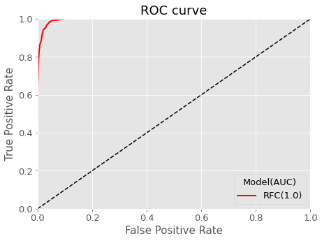

```python
# Dados de teste: obtendo as probabilidades da classe positiva (1):
y_test_preds = rfc.predict_proba(X_test)[:,1]

# Calculando o "FPR", "TPR" e "Thresholds":
fpr, tpr, thresholds = roc_curve(y_test, y_test_preds)

# Plot da "Curva ROC":
ptlib.plot_roc_curve(
    fpr, tpr, auc=rfc_test_mtcs['auc'], auc_decimals=2, plot_style='ggplot', color='red', line_width=2,
    title='ROC curve', title_fontsize=18, labels_fontsize=15, ticks_fontsize=13,
    legendtitle='Model(AUC)', legendtitle_fontsize=13, legend_label='RFC', legend_fontsize=13,
    width=7, height=5, figure_id=None, figure_path=GRAPHICS_PATH,
    figure_file_format="png", figure_file_extension=".png", tight_layout=True, dpi=300
)
```

**Análise:**

Podemos observar que o nosso classificador **`RFC`** apresentou uma *`ROC curve`* **muito próxima** do *canto superior esquerdo*. Observe também que a métrica **`AUC = 99.56%`** ficou **acima** do valor proposto de avaliação do projeto (**`AUC = ~99%`**).

## 5.6- [LDA](https://scikit-learn.org/stable/modules/generated/sklearn.discriminant_analysis.LinearDiscriminantAnalysis.html) (Linear Discriminant Analysis):

```python
# Inicia o treinamento e avaliação:
ept.start(msg="Iniciando o treinamento/avaliação com o 'LDA'...")

# Treinando e avalidando o classificador binário com o LDA:
lda, lda_train_mtcs, lda_test_mtcs = mllib.train_validate_binary_clf_model(
    classifier=models['LDA'], X_train=X_train_bal, y_train=y_train_bal, X_valid=X_test, y_valid=y_test, threshold=THRESHOLD
)

# Fim do treinamento e avaliação:
ept.end(msg="\nTempo gasto para o treinamento/avaliação com o 'LDA':")
```

```
Iniciando o treinamento/avaliação com o 'LDA'...

Training Metrics:
AUC      : 0.5797
Accuracy : 0.6065
Precision: 0.6321
Recall   : 0.5098
f1-score : 0.5644

Validation Metrics:
AUC      : 0.5167
Accuracy : 0.637
Precision: 0.2611
Recall   : 0.4457
f1-score : 0.3293

Tempo gasto para o treinamento/avaliação com o 'LDA': 0.13 seconds.
```

**Análise:**

1. com o classificador **`LDA`** obtivemos uma taxa de **acurácia** de **63.70%** nos dados de teste, ou seja, é a porcentagem de pacientes, classificados corretamente por ele, que **terão uma crise epilética** e que **não terão uma crise epilética**. Portanto, o nosso classificador **`LDA`** apresentou uma performance **boa**;
2. com o nosso classificador **`LDA`** obtivemos uma taxa de **precisão** de **26.11%** nos dados de teste, ou seja, é a porcentagem de pacientes, classificados corretamente por ele, que **terão uma crise epilética**. Portanto, o nosso modelo apresentou uma performance **muito ruim** porque em apenas **26%** dos pacientes ele acertou que os mesmos **terão uma crise epilética**;
3. com o nosso classificador **`LDA`** obtivemos uma taxa de **revocação** de **44.57%** nos dados de teste, ou seja, é a porcentagem de pacientes, que ele conseguiu detectar, que **terão uma crise epilética**. Portanto, o nosso modelo apresentou uma performance **muito ruim** porque em apenas **45%** dos pacientes ele conseguiu detectar que os mesmos **terão uma crise epilética**;
4. com o classificador **`LDA`** obtivemos uma **`pontuação F1`** **muito baixa**, porque as taxas de **precisão** e **revocação** também foram muito baixas.

### `ROC Curve`

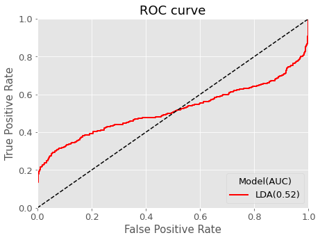

```python
# Dados de teste: obtendo as probabilidades da classe positiva (1):
y_test_preds = lda.predict_proba(X_test)[:,1]

# Calculando o "FPR", "TPR" e "Thresholds":
fpr, tpr, thresholds = roc_curve(y_test, y_test_preds)

# Plot da "Curva ROC":
ptlib.plot_roc_curve(
    fpr, tpr, auc=lda_test_mtcs['auc'], auc_decimals=2, plot_style='ggplot', color='red', line_width=2,
    title='ROC curve', title_fontsize=18, labels_fontsize=15, ticks_fontsize=13,
    legendtitle='Model(AUC)', legendtitle_fontsize=13, legend_label='LDA', legend_fontsize=13,
    width=7, height=5, figure_id=None, figure_path=GRAPHICS_PATH,
    figure_file_format="png", figure_file_extension=".png", tight_layout=True, dpi=300
)
```

**Análise:**

Podemos observar que o nosso classificador **`LDA`** apresentou uma *`ROC curve`* **muito distante** do *canto superior esquerdo*. Observe também que a métrica **`AUC = 51.67%`** ficou **muito abaixo** do valor proposto de avaliação do projeto (**`AUC = ~99%`**).

## 5.7- [NB](https://scikit-learn.org/0.15/modules/generated/sklearn.naive_bayes.GaussianNB.html) (Naive Bayes):

```python
# Inicia o treinamento e avaliação:
ept.start(msg="Iniciando o treinamento/avaliação com o 'NB'...")

# Treinando e avalidando o classificador binário com o NB:
nb, nb_train_mtcs, nb_test_mtcs = mllib.train_validate_binary_clf_model(
    classifier=models['NB'], X_train=X_train_bal, y_train=y_train_bal, X_valid=X_test, y_valid=y_test, threshold=THRESHOLD
)

# Fim do treinamento e avaliação:
ept.end(msg="\nTempo gasto para o treinamento/avaliação com o 'NB':")
```

```
Iniciando o treinamento/avaliação com o 'NB'...

Training Metrics:
AUC      : 0.9824
Accuracy : 0.9329
Precision: 0.9672
Recall   : 0.8962
f1-score : 0.9303

Validation Metrics:
AUC      : 0.9827
Accuracy : 0.9574
Precision: 0.8803
Recall   : 0.9109
f1-score : 0.8953

Tempo gasto para o treinamento/avaliação com o 'NB': 0.04 seconds.
```

**Análise:**

1. com o classificador **`NB`** obtivemos uma taxa de **acurácia** de **95.74%** nos dados de teste, ou seja, é a porcentagem de pacientes, classificados corretamente por ele, que **terão uma crise epilética** e que **não terão uma crise epilética**. Portanto, o nosso classificador **`NB`** apresentou uma performance **excelente**;
2. com o nosso classificador **`NB`** obtivemos uma taxa de **precisão** de **88.03%** nos dados de teste, ou seja, é a porcentagem de pacientes, classificados corretamente por ele, que **terão uma crise epilética**. Portanto, o nosso modelo apresentou uma performance **muito boa** porque em **88%** dos pacientes ele acertou que os mesmos **terão uma crise epilética**;
3. com o nosso classificador **`NB`** obtivemos uma taxa de **revocação** de **91.09%** nos dados de teste, ou seja, é a porcentagem de pacientes, que ele conseguiu detectar, que **terão uma crise epilética**. Portanto, o nosso modelo apresentou uma performance **excelente** porque em **91%** dos pacientes ele conseguiu detectar que os mesmos **terão uma crise epilética**;
4. com o classificador **`NB`** obtivemos uma **`pontuação F1`** **muito alta**, porque as taxas de **precisão** e **revocação** também foram muito altas.

### `ROC Curve`

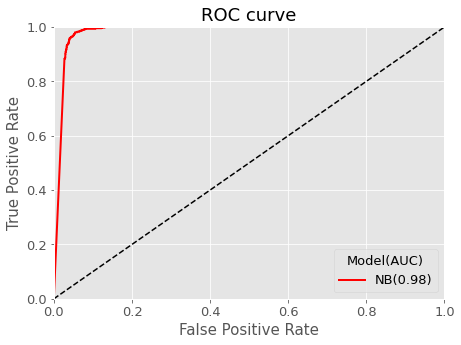

```python
# Dados de teste: obtendo as probabilidades da classe positiva (1):
y_test_preds = nb.predict_proba(X_test)[:,1]

# Calculando o "FPR", "TPR" e "Thresholds":
fpr, tpr, thresholds = roc_curve(y_test, y_test_preds)

# Plot da "Curva ROC":
ptlib.plot_roc_curve(
    fpr, tpr, auc=nb_test_mtcs['auc'], auc_decimals=2, plot_style='ggplot', color='red', line_width=2,
    title='ROC curve', title_fontsize=18, labels_fontsize=15, ticks_fontsize=13,
    legendtitle='Model(AUC)', legendtitle_fontsize=13, legend_label='NB', legend_fontsize=13,
    width=7, height=5, figure_id=None, figure_path=GRAPHICS_PATH,
    figure_file_format="png", figure_file_extension=".png", tight_layout=True, dpi=300
)
```

**Análise:**

Podemos observar que o nosso classificador **`NB`** apresentou uma *`ROC curve`* **muito próxima** do *canto superior esquerdo*. Observe também que a métrica **`AUC = 98.27%`** ficou **muito próxima** do valor proposto de avaliação do projeto (**`AUC = ~99%`**).

## 5.8- [XGBC](https://xgboost.readthedocs.io/en/latest/python/python_api.html?highlight=xgbclassifier#xgboost.XGBClassifier) (XGBoost Classifier):

```python
# Inicia o treinamento e avaliação:
ept.start(msg="Iniciando o treinamento/avaliação com o 'XGBC'...")

# Treinando e avalidando o classificador binário com o XGBC:
xgbc, xgbc_train_mtcs, xgbc_test_mtcs = mllib.train_validate_binary_clf_model(
    classifier=models['XGBC'], X_train=X_train_bal, y_train=y_train_bal, X_valid=X_test, y_valid=y_test, threshold=THRESHOLD
)

# Fim do treinamento e avaliação:
ept.end(msg="\nTempo gasto para o treinamento/avaliação com o 'XGBC':")
```

```
Iniciando o treinamento/avaliação com o 'XGBC'...

Training Metrics:
AUC      : 0.9991
Accuracy : 0.9845
Precision: 0.9912
Recall   : 0.9777
f1-score : 0.9844

Validation Metrics:
AUC      : 0.9929
Accuracy : 0.9574
Precision: 0.8679
Recall   : 0.9283
f1-score : 0.8971

Tempo gasto para o treinamento/avaliação com o 'XGBC': 0.75 seconds.
```

### `ROC Curve`

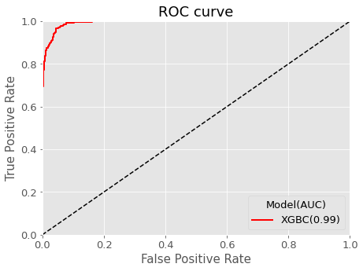

```python
# Dados de teste: obtendo as probabilidades da classe positiva (1):
y_test_preds = xgbc.predict_proba(X_test)[:,1]

# Calculando o "FPR", "TPR" e "Thresholds":
fpr, tpr, thresholds = roc_curve(y_test, y_test_preds)

# Plot da "Curva ROC":
ptlib.plot_roc_curve(
    fpr, tpr, auc=xgbc_test_mtcs['auc'], auc_decimals=2, plot_style='ggplot', color='red', line_width=2,
    title='ROC curve', title_fontsize=18, labels_fontsize=15, ticks_fontsize=13,
    legendtitle='Model(AUC)', legendtitle_fontsize=13, legend_label='XGBC', legend_fontsize=13,
    width=7, height=5, figure_id=None, figure_path=GRAPHICS_PATH,
    figure_file_format="png", figure_file_extension=".png", tight_layout=True, dpi=300
)
```

**Análise:**

Podemos observar que o nosso classificador **`XGBC`** apresentou uma *`ROC curve`* **muito próxima** do *canto superior esquerdo*. Observe também que a métrica **`AUC = 99.29%`** ficou **acima** do valor proposto de avaliação do projeto (**`AUC = ~99%`**).

## 6- Conclusão

### Salvando as métricas de classificação (`v2`):

```python
# Criando um data frame para armazenar as métricas:
clf_metrics_v2 = pd.DataFrame(
    {'model':['SGD','SGD','KNN','KNN','LR','LR','DTC','DTC','RFC','RFC','LDA','LDA','NB','NB','XGBC','XGBC'],
     'data set':['train','test']*8,
     'auc':[sgd_train_mtcs['auc'],sgd_test_mtcs['auc'],knn_train_mtcs['auc'],knn_test_mtcs['auc'],lr_train_mtcs['auc'],lr_test_mtcs['auc'],dtc_train_mtcs['auc'],dtc_test_mtcs['auc'],rfc_train_mtcs['auc'],rfc_test_mtcs['auc'],lda_train_mtcs['auc'],lda_test_mtcs['auc'],nb_train_mtcs['auc'],nb_test_mtcs['auc'],xgbc_train_mtcs['auc'],xgbc_test_mtcs['auc']],
     'accuracy':[sgd_train_mtcs['accuracy'],sgd_test_mtcs['accuracy'],knn_train_mtcs['accuracy'],knn_test_mtcs['accuracy'],lr_train_mtcs['accuracy'],lr_test_mtcs['accuracy'],dtc_train_mtcs['accuracy'],dtc_test_mtcs['accuracy'],rfc_train_mtcs['accuracy'],rfc_test_mtcs['accuracy'],lda_train_mtcs['accuracy'],lda_test_mtcs['accuracy'],nb_train_mtcs['accuracy'],nb_test_mtcs['accuracy'],xgbc_train_mtcs['accuracy'],xgbc_test_mtcs['accuracy']],
     'precision':[sgd_train_mtcs['precision'],sgd_test_mtcs['precision'],knn_train_mtcs['precision'],knn_test_mtcs['precision'],lr_train_mtcs['precision'],lr_test_mtcs['precision'],dtc_train_mtcs['precision'],dtc_test_mtcs['precision'],rfc_train_mtcs['precision'],rfc_test_mtcs['precision'],lda_train_mtcs['precision'],lda_test_mtcs['precision'],nb_train_mtcs['precision'],nb_test_mtcs['precision'],xgbc_train_mtcs['precision'],xgbc_test_mtcs['precision']],
     'recall':[sgd_train_mtcs['recall'],sgd_test_mtcs['recall'],knn_train_mtcs['recall'],knn_test_mtcs['recall'],lr_train_mtcs['recall'],lr_test_mtcs['recall'],dtc_train_mtcs['recall'],dtc_test_mtcs['recall'],rfc_train_mtcs['recall'],rfc_test_mtcs['recall'],lda_train_mtcs['recall'],lda_test_mtcs['recall'],nb_train_mtcs['recall'],nb_test_mtcs['recall'],xgbc_train_mtcs['recall'],xgbc_test_mtcs['recall']],
     'f1-score':[sgd_train_mtcs['f1_score'],sgd_test_mtcs['f1_score'],knn_train_mtcs['f1_score'],knn_test_mtcs['f1_score'],lr_train_mtcs['f1_score'],lr_test_mtcs['f1_score'],dtc_train_mtcs['f1_score'],dtc_test_mtcs['f1_score'],rfc_train_mtcs['f1_score'],rfc_test_mtcs['f1_score'],lda_train_mtcs['f1_score'],lda_test_mtcs['f1_score'],nb_train_mtcs['f1_score'],nb_test_mtcs['f1_score'],xgbc_train_mtcs['f1_score'],xgbc_test_mtcs['f1_score']]
    }
)

# Salvando as métricas (objeto "clf_metrics_df") na pasta "./objects":
dslib.pickle_object_save (
    path=OBJ_PATH, file="clf_metrics_v2.pck", object_name=clf_metrics_v2,
    msg="O arquivo 'clf_metrics_v2.pck' (object) foi salvo com sucesso!"
)
```

```
O arquivo 'clf_metrics_v2.pck' (object) foi salvo com sucesso!
```

### Avaliando a métrica `AUC` nos *datasets* de treino e de teste:

Primeiro, vamos plotar um gráfico de barras para avaliarmos o desempenho de cada modelo em relação aos dados de treino e de teste.

```
Saving figure: plot_auc_train_vs_test_v2
```

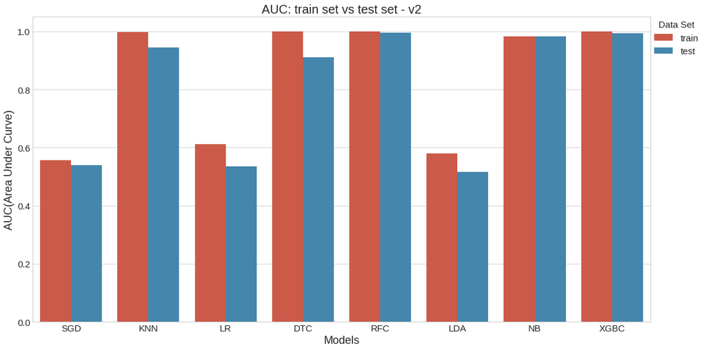

```python
# Comparando a métrica "AUC" dos modelos nos dados de treino e teste:
ptlib.plot_ml_metrics(
    data=clf_metrics_v2, x='model', y='auc', hue='data set', plot_style='seaborn-whitegrid', title="AUC: train set vs test set - v2",
    title_fontsize=20, xlabel="Models", xlabel_fontsize=18, ylabel="AUC(Area Under Curve)", ylabel_fontsize=18,
    ticks_fontsize=15, legendtitle="Data Set", legendtitle_fontsize=15, legend_label=None, legend_fontsize=15,
    legend_loc=2, legend_borderaxespad=0., legend_bbox_to_anchor=(1, 1), width=16, height=8,
    figure_id='plot_auc_train_vs_test_v2', figure_path=GRAPHICS_PATH,
    figure_file_format="png", figure_file_extension=".png", tight_layout=True, dpi=300
)
```

**Análise:** podemos observar que os modelos que apresentaram um desempenho melhor, nos dados de treino e teste, foram: **`KNN`**, **`RFC`**, **`NB`** e **`XGBC`**.

Agora, vamos avaliar os resultados das métricas **`AUC`** e **`Recall`** considerando apenas os dados de teste.

### Avaliando as métricas `AUC` e `Recall` nos dados de teste:

Agora, vamos plotar um gráfico comparando as métricas **`AUC`** e as métricas de revocação (**`Recall`**), de cada modelo, e então vamos definir qual dos modelos atende as necessidades do projeto para resolver o problema de negócio para o qual ele foi criado:

### `AUC`

```
Saving figure: plot_models_vs_auc_v2
```

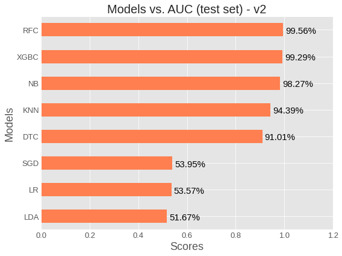

```python
# Criando um objeto (Serie) com os valores da métrica "AUC" classificados em ordem descrescente:
# Criando um índice para selecionarmos apenas as linhas referente aos dados de teste:
index = clf_metrics_v2['data set'] == 'test'
# Classificando as taxas de "AUC":
models_auc = clf_metrics_v2.loc[index, ['model','auc']].set_index(keys='model')['auc'].sort_values(ascending=False)

# Plot: models vs AUC
ptlib.plot_models_vs_scores(
    scores=models_auc, plot_style='ggplot', bar_color='coral', alpha=0.8,
    score_color='black', score_fontsize=15, title="Models vs. AUC (test set) - v2",
    title_fontsize=20, xlabel="Scores", xlabel_fontsize=18, ylabel='Models',
    ylabel_fontsize=18, ticks_fontsize=13, width=8, height=6,
    figure_id='plot_models_vs_auc_v2', figure_path=GRAPHICS_PATH,
    figure_file_format="png", figure_file_extension=".png", tight_layout=True, dpi=300
)
```

### `Recall`

```
Saving figure: plot_models_vs_recall_v2
```

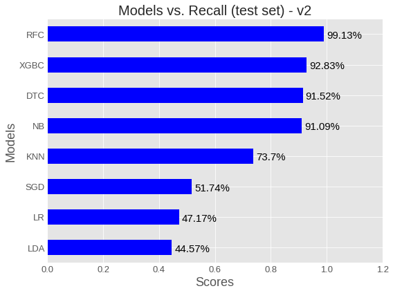

```python
# Criando um objeto (Serie) com os valores da métrica "Recall" classificados em ordem descrescente:
# Criando um índice para selecionarmos apenas as linhas referente aos dados de teste:
index = clf_metrics_v2['data set'] == 'test'
# Classificando as taxas de "Recall":
models_recall = clf_metrics_v2.loc[index, ['model','recall']].set_index(keys='model')['recall'].sort_values(ascending=False)

# Plot: models vs AUC
ptlib.plot_models_vs_scores(
    scores=models_recall, plot_style='ggplot', bar_color='blue', alpha=0.8,
    score_color='black', score_fontsize=15, title="Models vs. Recall (test set) - v2",
    title_fontsize=20, xlabel="Scores", xlabel_fontsize=18, ylabel='Models',
    ylabel_fontsize=18, ticks_fontsize=13, width=8, height=6,
    figure_id='plot_models_vs_recall_v2', figure_path=GRAPHICS_PATH,
    figure_file_format="png", figure_file_extension=".png", tight_layout=True, dpi=300
)
```

**Análise:** de acordo com as métricas **`AUC`**, para a versão **`v2`** dos modelos preditivos, dois modelos tiveram um desempenho satisfatório e podem ser utilizados para solucionar o problema de negócio, ou seja, **prever se o paciente terá uma crise epilética**. São eles:

1. **`RFC`**: **AUC = 99.56%**;
2. **`XGBC`**: **AUC = 99.29%**.

Os dois modelos previtivos conseguiram obter na versão **v2**, na métrica **AUC**, o valor mínimo desejado para o projeto que é de **99%**.

Entretanto, vamos escolher o modelo **`RFC`** (*Random Forest Classifier*) porque ele apresentou a melhor performance na métrica de revocação (**`Recall`**) entre os modelos, ou seja, em **~99%** dos pacientes ele conseguiu detectar que os mesmos **terão uma crise epilética**.

Portanto, para a versão **`v2`** dos modelos preditivos a minha escolha é o modelo criado com o algoritmo **`RFC`** (*Random Forest Classifier*).

### Salvando o modelo preditivo (**`v2`**) escolhido:

```python
# Salvando o modelo preditivo "rfc" (Random Forest Classifier):
dslib.pickle_object_save (
    path=ML_PATH, file="rfc_best_model_v2.pck", object_name=rfc,
    msg="O arquivo 'rfc_best_model_v2.pck' (modelo preditivo) foi salvo com sucesso!"
)
```

```
O arquivo 'rfc_best_model_v2.pck' (modelo preditivo) foi salvo com sucesso!
```

### Avaliando o melhor modelo preditivo entre as versões `v1` e `v2`:

```python
# Carregando as métricas da versão "v1" dos modelos:
clf_metrics_v1 = dslib.pickle_object_load(
    path=OBJ_PATH, file="clf_metrics_v1.pck",
    msg="O arquivo 'clf_metrics_v1.pck' (data frame) foi carregado com sucesso!"
)
```

```
O arquivo 'clf_metrics_v1.pck' (data frame) foi carregado com sucesso!
```

```python
# Filtrando as métricas da versão "v1" do modelo "RFC":
# Criando um índice para selecionarmos apenas as linhas referente aos dados de teste do modelo "RFC":
index = (clf_metrics_v1['data set'] == 'test') & (clf_metrics_v1['model'] == 'RFC')
rfc_metrics_v1 = clf_metrics_v1[index]
rfc_metrics_v1['version'] = 'v1'

# Filtrando as métricas da versão "v2" do modelo "RFC":
# Criando um índice para selecionarmos apenas as linhas referente aos dados de teste do modelo "RFC":
index = (clf_metrics_v2['data set'] == 'test') & (clf_metrics_v2['model'] == 'RFC')
rfc_metrics_v2 = clf_metrics_v2[index]
rfc_metrics_v2['version'] = 'v2'

# Criando um data frame com as métricas "v1" e "v2" do "RFC":
rfc_metrics = pd.concat(objs=[rfc_metrics_v1,rfc_metrics_v2], axis=0, ignore_index=True)
rfc_metrics
```

|  | model | data set | auc | accuracy | precision | recall | f1-score | version |
| --- | --- | --- | --- | --- | --- | --- | --- | --- |
| 0 | RFC | test | 0.9965 | 0.9696 | 0.8824 | 0.9783 | 0.9278 | v1 |
| 1 | RFC | test | 0.9956 | 0.9539 | 0.8172 | 0.9913 | 0.8959 | v2 |

**Análise:** a versão **`v1`** do modelo preditivo **`RFC`** apresentou o melhor desempenho na métrica **`AUC`** e portanto é o modelo final escolhido para solucionar o problema de negócio, ou seja, **prever se o paciente terá uma crise epilética**.